# act_report

## WeRateDogs Twitter Exploratory Data Analysis Report

**In this project I wrangled the WeRateDogs twitter data and created a master dataset for Exploratory Data Analysis(EDA).**

The first question I had was: Which dog has the highest rating (by WeRateDogs)? By querying the data and selecting the maximum 'rating_numerator' record, we found the highest rating dog is quite American! His name is Atticus, and a whopping rating of 1776 represents the year of independence! Interestingly, the image prediction recognized the picture as a non-dog bow_tie.. which is 50% correct. (see photo below)

[figure not shown]

Next, I was interested in finding out which dog is most favored by twitter readers? So I queried the data again selecting the record(tweet) with most 'favorite_count'. And it appears that a Labrador doggo who can stand in the swimming pool was the star! He/She had a total of 160808 favorite counts and was rating 13/10 by WeRateDogs. Also, the neural network prediction worked pretty well this time! (see photo below)

[figure not shown]

Moving on, I made a copy of the 'twitter_archive_master' dataframe and drop the record with the rating 1776/10 as it is the only big outlier for the 'rating_numerator'. Then, I plotting a set of histogram which showed the distribution of various numeric variables in our dataset.

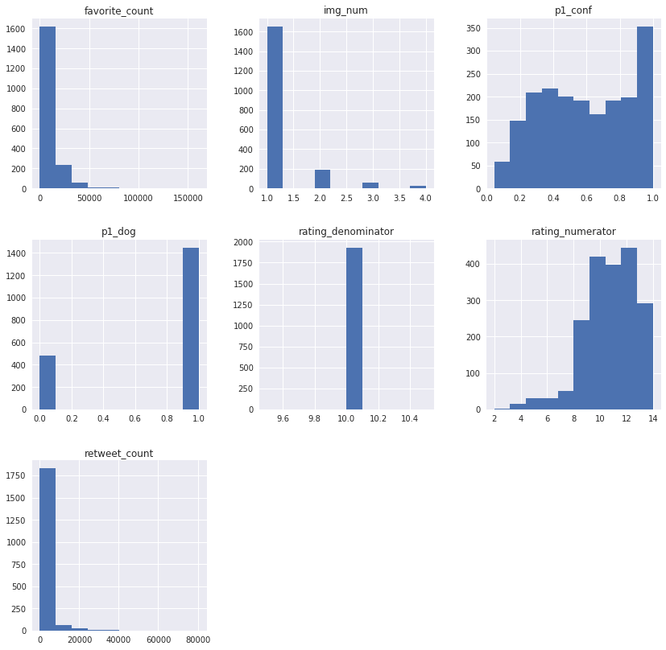

From the data above, we observed some interesting trends. First, the favorite count and retweet count distribution is Right-Skewed. Most of the tweets' favaorite count and retweet count are below 10000. Second, the rating numerator distribution is Left-Skewed, meaning more dogs are rating as higher ratings than lower ratings. Third, we see that the algorithm #1 prediction confidence rate had a peek between 0.9-1.0. Then, I looked into the favorite count distribution and plotted a better histogram as below.

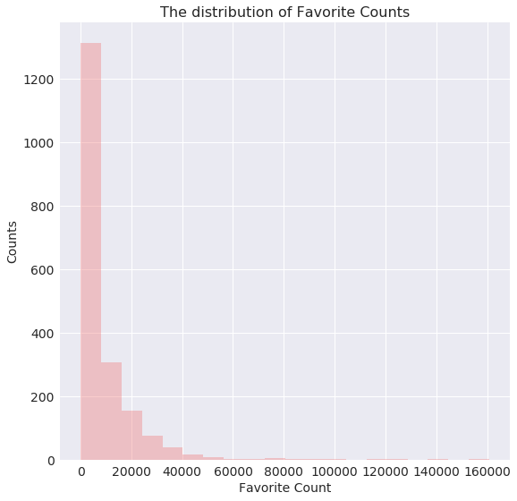

Again, we discovered most tweets have favorite counts less than 10000 and the distribution is Right-Skewed.

Finally, I looked at the relationships between two numeric variables using a scatter matrix plot.

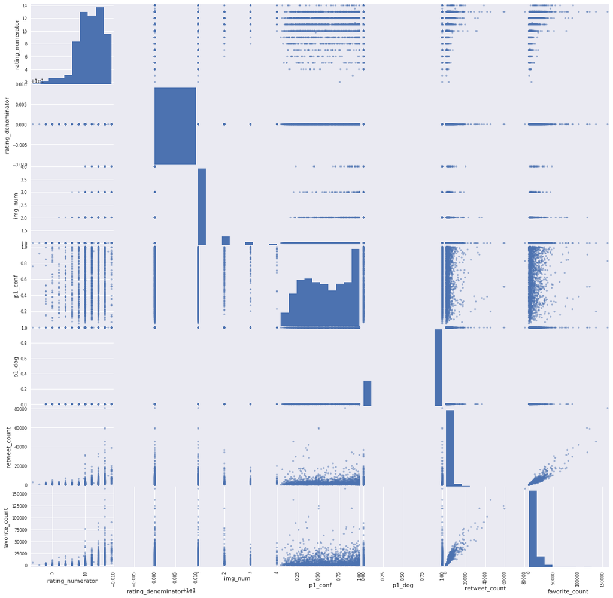

From the scatter matrix, I identified two sets of interesting relationships: 1. Strong positive correlation between the retweet count and favorite count. 2. A weaker positive relationship between the rating numerator and favorite/retweet count. I plotted them individually as below:

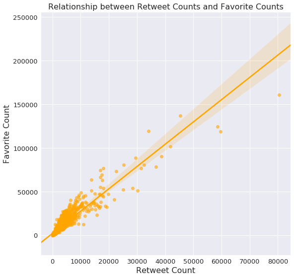

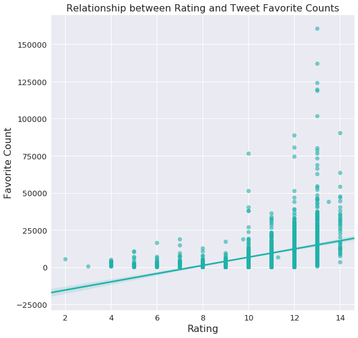

In summary, more exploratory work could be done for this project. And that is my next goal.